# Meta-Analytic Structural Equation Modeling

## Stage 1 analysis on the corrected correlations

```r
rand1.cor <- tssem1(my.corcor, df$N, method="REM")
summary(rand1.cor)
```

```
##
## Call:
## meta(y = ES, v = acovR, RE.constraints = Diag(paste0(RE.startvalues,
##     "*Tau2_", 1:no.es, "_", 1:no.es)), RE.lbound = RE.lbound,
##     I2 = I2, model.name = model.name, suppressWarnings = TRUE,
##     silent = silent, run = run)
##
## 95% confidence intervals: z statistic approximation (robust=FALSE)
## Coefficients:
##             Estimate Std.Error    lbound    ubound z value  Pr(>|z|)
## Intercept1 0.4711710 0.0286759 0.4149672 0.5273747 16.4309 < 2.2e-16 ***
## Intercept2 0.7521952 0.0226856 0.7077322 0.7966582 33.1574 < 2.2e-16 ***
## Intercept3 0.3697393 0.0216271 0.3273509 0.4121277 17.0961 < 2.2e-16 ***
## Intercept4 0.3712263 0.0214357 0.3292132 0.4132395 17.3182 < 2.2e-16 ***
## Intercept5 0.7503110 0.0190910 0.7128932 0.7877287 39.3018 < 2.2e-16 ***
## Intercept6 0.4786721 0.0256026 0.4284919 0.5288523 18.6962 < 2.2e-16 ***
## Tau2_1_1   0.0240498 0.0064316 0.0114442 0.0366555  3.7393 0.0001845 ***
## Tau2_2_2   0.0157601 0.0040642 0.0077944 0.0237257  3.8778 0.0001054 ***
## Tau2_3_3   0.0120713 0.0034840 0.0052429 0.0188998  3.4648 0.0005306 ***
## Tau2_4_4   0.0117874 0.0033716 0.0051791 0.0183957  3.4960 0.0004722 ***
## Tau2_5_5   0.0108101 0.0028611 0.0052024 0.0164178  3.7783 0.0001579 ***
## Tau2_6_6   0.0187186 0.0050347 0.0088508 0.0285865  3.7179 0.0002009 ***
## ---
## Signif. codes:  0 '***' 0.001 '**' 0.01 '*' 0.05 '.' 0.1 ' ' 1
##
## Q statistic on the homogeneity of effect sizes: 6870.735
## Degrees of freedom of the Q statistic: 186
## P value of the Q statistic: 0
##
## Heterogeneity indices (based on the estimated Tau2):
##                              Estimate
## Intercept1: I2 (Q statistic)   0.9447
## Intercept2: I2 (Q statistic)   0.9750
## Intercept3: I2 (Q statistic)   0.8679
## Intercept4: I2 (Q statistic)   0.8642
## Intercept5: I2 (Q statistic)   0.9563
## Intercept6: I2 (Q statistic)   0.9297
##
## Number of studies (or clusters): 32
## Number of observed statistics: 192
## Number of estimated parameters: 12
## Degrees of freedom: 180
## -2 log likelihood: -227.4803
## OpenMx status1: 0 ("0" or "1": The optimization is considered fine.
## Other values may indicate problems.)
```

## Stage 2 analysis on the corrected correlations

```r
rand2.cor <- tssem2(rand1.cor, RAM=RAM1)
summary(rand2.cor)
```

```
##
## Call:
## wls(Cov = pooledS, aCov = aCov, n = tssem1.obj$total.n, RAM = RAM,
##     Amatrix = Amatrix, Smatrix = Smatrix, Fmatrix = Fmatrix,
##     diag.constraints = diag.constraints, cor.analysis = cor.analysis,
##     intervals.type = intervals.type, mx.algebras = mx.algebras,
##     mxModel.Args = mxModel.Args, subset.variables = subset.variables,
##     model.name = model.name, suppressWarnings = suppressWarnings,
##     silent = silent, run = run)
##
## 95% confidence intervals: z statistic approximation
## Coefficients:
##           Estimate Std.Error    lbound    ubound z value  Pr(>|z|)
## s2s       0.740491  0.029552  0.682569  0.798413 25.0568 < 2.2e-16 ***
## w2s       0.020841  0.038524 -0.054664  0.096347  0.5410    0.5885
## s2w       0.021612  0.039009 -0.054844  0.098068  0.5540    0.5796
## w2w       0.742012  0.033438  0.676474  0.807550 22.1905 < 2.2e-16 ***
## w1withs1  0.471171  0.028676  0.414967  0.527375 16.4309 < 2.2e-16 ***
## w2withs2  0.188106  0.035367  0.118787  0.257424  5.3187 1.045e-07 ***
## ---
## Signif. codes:  0 '***' 0.001 '**' 0.01 '*' 0.05 '.' 0.1 ' ' 1
##
## Goodness-of-fit indices:
##                                              Value
## Sample size                                12906.0
## Chi-square of target model                     0.0
## DF of target model                             0.0
## p value of target model                        0.0
## Number of constraints imposed on "Smatrix"     0.0
## DF manually adjusted                           0.0
## Chi-square of independence model            3398.8
## DF of independence model                       6.0
## RMSEA                                          0.0
## RMSEA lower 95% CI                             0.0
## RMSEA upper 95% CI                             0.0
## SRMR                                           0.0
## TLI                                           -Inf
## CFI                                            1.0
## AIC                                            0.0
## BIC                                            0.0
## OpenMx status1: 0 ("0" or "1": The optimization is considered fine.
## Other values indicate problems.)
```

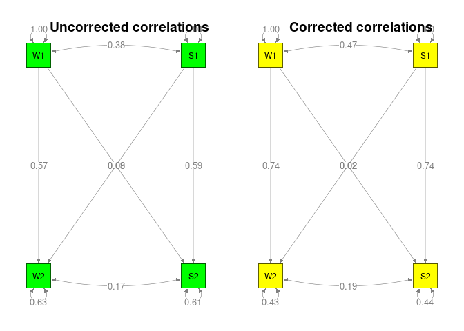

```r
## Setup two plots side-by-side
layout(t(1:2))

## Plot the first group
plot(rand2a, col="green")
title("Uncorrected correlations")

## Plot the second group
plot(rand2.cor, col="yellow")
title("Corrected correlations")
```

[^1]: Rushton, J. P., & Irwing, P. (2011). The general factor of personality. In T. Chamorro-Premuzic, S. von Stumm, & A. Furnham (Eds.), *The Wiley-Blackwell Handbook of Individual Differences* (pp. 132–161). Wiley-Blackwell. http://onlinelibrary.wiley.com.libproxy1.nus.edu.sg/doi/10.1002/9781444343120.ch5/summary
[^2]: Nohe, C., Meier, L. L., Sonntag, K., & Michel, A. (2015). The chicken or the egg? A meta-analysis of panel studies of the relationship between work–family conflict and strain. *Journal of Applied Psychology*, *100*(2), 522–536. https://doi.org/10.1037/a0038012
[^3]: Cheung, M. W.-L. (2009). Constructing approximate confidence intervals for parameters with structural equation models. *Structural Equation Modeling: A Multidisciplinary Journal*, *16*(2), 267–294. https://doi.org/10.1080/10705510902751291